# Relación entre estructura secundaria y terciaria

# 1evzvd vs 1cc5a:

Observamos que el sobrelape se encuentra en la región de las alfa-hélices, lo que hace sentido ya que la superfamilia de las citocromo son alfa-hélices. También podemos observar que las regiones loop presentan cierto grado de sobrelape indicando así un gran grado de similitud.

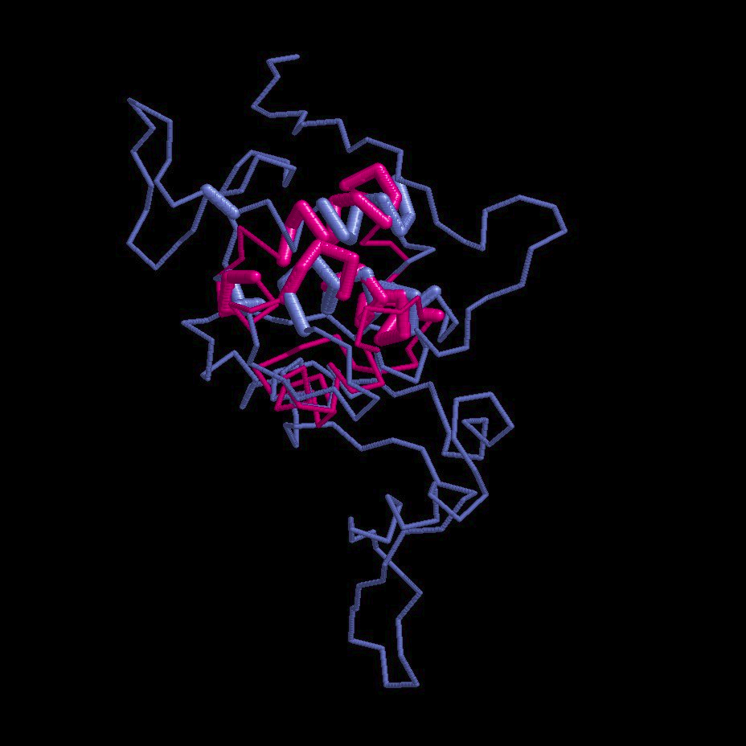

```python
Image(filename="/home/ajimenez/LCG/4Sem/Bioinfo/Semana2/tarea3/Imagen1.png")
```

# 1evzd vs 1e8ea:

De la misma manera, observamos sobrelape con alfa-helice. También presenta sobrelape con zonas loop, quizá esas zonas sean relevantes para mantener la estructura de la proteína y por lo tanto se conservan. En éste caso podemos observar una gran diferencia en las regiones loop.

De las imágenes podemos concluir que 1evzd es más similar a 1cc5a que a 1e8ea.

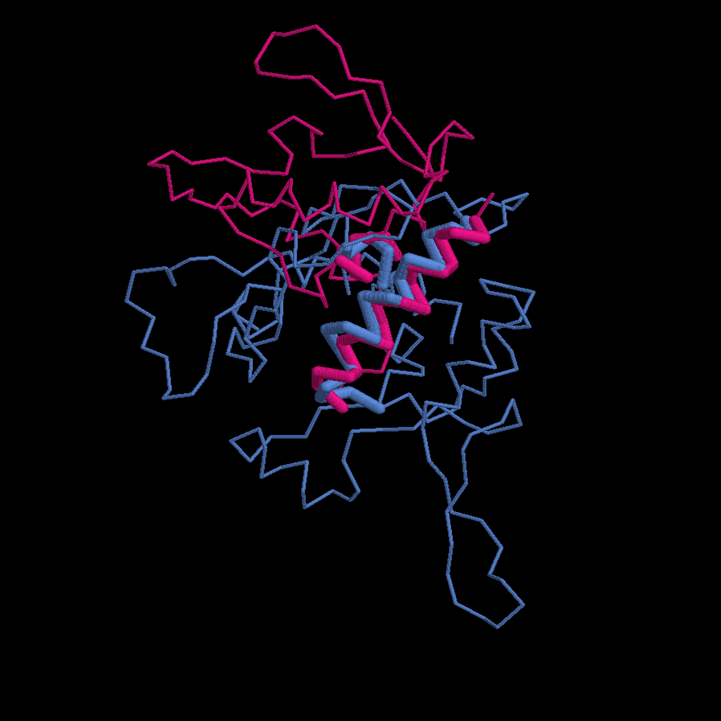

```python
Image(filename="/home/ajimenez/LCG/4Sem/Bioinfo/Semana2/tarea3/Imagen2.png")
```

##### 5) Utiliza el prog3.1 (en http://eead-csic-compbio.github.io/bioinformatica_estructural/node31.html) para calcular el error (RMSD) de los alineamientos obtenidos en 3 y 4 y comenta los resultados. Son mejores o peores los alineamientos basados en secuencia desde el punto de vista del RMSD?

**Resultados: 1evzvd vs 1cc5a**

- RMSD = 9.53 Angstrom

**Resultados: 1evzvd vs 1e8ea:**

- RMSD = 1.83 Angstrom

**Alineamiento MAMMOTH de 1evzvd vs 1cc5a**

_______________________________________________________________________________ T U R B O M A M M O T H MAtching Molecular Models Obtained from THeory _______________________________________________________________________________ ------------------- Input information ------------------- ==> PREDICTION: Filename: d1evzvd1.pdbd Number of residues: 199 ==> EXPERIMENT: Filename: c1cc5a.pdbd Number of residues: 83 ----------------------------- Structural Alignment Scores ----------------------------- PSI(ini)= 98.80 NALI= 82 NORM= 83 RMS= 13.24 NSS= 57 PSI(end)= 36.14 NALI= 30 NORM= 83 RMS= 3.89 Sstr(LG)= 1048.09 NALI= 30 NORM= 83 RMS= 3.89 E-value= 0.69690228E-01 Z-score= 2.3566000 -ln(E)= 2.6636952 ---------------------------- Final Structural Alignment ---------------------------- Prediction MTAAEHGLHA PAYAWSHNGP FETFDHASIR RGYQVYREVC AACHSLDRVA Prediction HHHHHHHHHH HHHH-SSS-- --HHHHHHHH HHHHHHHHHH H--HHHHHHH |||| Experiment ---------- ---------- ---------- ---------- ----SSS--H Experiment .......... .......... .......... .......... ....GGGARS Prediction WRTLVGVSHT NEEVRNMAEE FEYDDEPDEQ GNPKKRPGKL SDYIPGPYPN Prediction HHHHH---HH HHHHHHHHHH HHHHHHH--- --SSSSSS-- --SSSSSSSS ||| | |||||||| | |||||| ||| Experiment HHH------H HHHHHHHHHH --------HH ----SS---- -------HHH Experiment GDD......V VAKYCNACHG ........TG LLNAPKVGD. .......SAA ******* ** ** Prediction EQAARAANQG ALPPDLSLIV KARHGGCDYI FSLLTGYPDE PPAGVALPPG Prediction --SSSS---- -SSSS--SSS SS--HHHHHH HHHHHHHHHH HH---SS--- ||||| ||||||| || | |||| Experiment HHHHHH---- ---------- ---SSS-HHH HH----HH-- ----HHH--- Experiment WKTRAD.... ....A..... ...KGGLDGL LA....QS.. ....LSGLN. ******* ** ** **** ********** ***** Prediction SNYNPYFPGG SIAMARVLFD DMVEYEDGTP ATTSQMAKDV TTFLNWCA Prediction -SS------- HHHHHHHHHH HHHH-----S S---HHHHHH HHHHHHHH | || ||||||||| Experiment ---------- ------SSS- -----SSS-- SS-HHHHHHH HHHHH--- Experiment .......A.. .....MPPK. .....GTCAD CSDDELKAAI GKMSG... **** ********** ***** --------- Timings --------- < Initialization: 0.016 sec > < Secondary Structure assignment 0.000 sec > < Structure alignment: 0.016 sec > < Tertiary structure matching: 0.004 sec > < Text Output 0.000 sec >

**Alineamiento MAMMOTH de 1evzvd vs 1e8ea**:

_______________________________________________________________________________ T U R B O M A M M O T H MAtching Molecular Models Obtained from THeory _______________________________________________________________________________ ------------------- Input information ------------------- ==> PREDICTION: Filename: 1e8e.pdbd Number of residues: 124 ==> EXPERIMENT: Filename: d1evzvd1.pdbd Number of residues: 199 ----------------------------- Structural Alignment Scores ----------------------------- PSI(ini)= 95.97 NALI= 119 NORM= 124 RMS= 14.08 NSS= 73 PSI(end)= 23.39 NALI= 29 NORM= 124 RMS= 3.22 Sstr(LG)= 977.70 NALI= 29 NORM= 124 RMS= 3.22 E-value= 0.13354469 Z-score= 1.6246705 -ln(E)= 2.0133191 ---------------------------- Final Structural Alignment ---------------------------- ****** ********** ***** Prediction .......... .......... ...DVTNAEK LVYKYTNIAH SANPMYEAPS Prediction ---------- ---------- ---HHHHHHH HHHHHHHHHH H----HHHHH ||||||| ||||||| | ||||| Experiment HHHHHHHHHH HHHH-SSS-- --HHHHHHHH HHHHHHHHHH H--HHHHHHH Experiment MTAAEHGLHA PAYAWSHNGP FETFDHASIR RGYQVYREVC AACHSLDRVA ****** ********** ***** Prediction I........T D...GKIFFN R...KFKTPS GKEA.....A CASCHTNNPA Prediction H--------H H---HHHHHH H---HHH--- --HH-----H HHHHHHH--- | | | |||||| | |||||| ||| | Experiment HHHHH---HH HHHHHHHHHH HHHHHHH--- --SSSSSS-- --SSSSSSSS Experiment WRTLVGVSHT NEEVRNMAEE FEYDDEPDEQ GNPKKRPGKL SDYIPGPYPN Prediction NVG.KNIVTG KEIPPLAPRV NTKRFTDIDK VED.....EF T........K Prediction --S-SS---- -SSSSS---- ---SSSS--H HHH-----HH H--------H |||| | |||||| ||| || Experiment --SSSS---- -S--SSS--S SSSS--HHHH HHHHHHHHHH HHHH---SS- Experiment EQAARAANQG AL..PPDLSL IVKARHGGCD YIFSLLTGYP DEPPAGVALP * *** **** Prediction HC........ NDI....... .LGA...... .DCSPSEKAN FIAYLLTETK Prediction HH-------- H--------- ---H------ -HHHHHHHHH HHHHHHHHHH | ||| ||||||||| |||| Experiment ---SS----- --HHHHHHHH HHHHHH---- -SS---HHHH HHHHHHHHHH Experiment PGSNYNPYFP GGSIAMARVL FDDMVEYEDG TPATTSQMAK DVTTFLNWCA * *** **** Prediction PT Prediction HH Experiment -- Experiment .. --------- Timings --------- < Initialization: 0.020 sec > < Secondary Structure assignment 0.000 sec > < Structure alignment: 0.024 sec > < Tertiary structure matching: 0.004 sec > < Text Output 0.000 sec >

**Nuevos RMSD**

- 1evzvd vs 1cc5a: 6.72 Angstrom
- 1evzvd vs 1e8ea: 8.75 Angstrom

## Discusión:

**Primer alineamiento**

El RSMD del primer alineamiento (1evzvd vs 1cc5a) es mucho mejor al original considerando que MAMMOTH alinea toda la secuencia (en contraste de la localidad del alineamiento de BLAST) lo que indica que el alineamiento recupera información más relevante.

**Segundo alinemiento**

El RMSD aumento con el alineamiento de MAMMOTH, pero una vez más, considerando que el alineamiento de BLAST tiene una cobertura de 3% el programa tiene muy pocos aminoácidos que comparar y por lo tanto el error será bajo.

Si tan solo en el 3% de la secuencia hubo un error de 1.83 Angstroms uno esperaría que al cubrir el 100% el error aumentría en forma proporcional pero no es el caso, una vez más demostrando que la comparación por estructura da resultados mejores

**El RMSD obtenido del alineamiento de BLAST nos da una noción de similitud erronea**

El RMSD del segundo alineamiento con BLAST fue menor al del primero, sugiriendo que 1evzvd es más similar a 1e8ea que a 1cc5a resultado contrario a lo que se había concluido con las imágenes de rasmol.

## Conclusiones

Para encontrar similitudes entre proteínas es mucho mejor utilizar algoritmos que consideren la estructura en vez de la secuencia. Las estructuras se conservan a pesar que las secuencias divergan mucho, especialmente para proteínas lejanamente emparentadas, en otras palabras, comparar por estructura nos da más información de la similitud entre dos proteínas.

También hay que cuidar mucho con que tipo de algoritmos se realice el alineamiento, lo que conviene en éste contexto particular es utilizar un algoritmo que alinee de manera global.